# Zero-inflation 0️⃣

Published

March 27, 2025

# 1 Introduction

This tutorial demonstrates how to analyze zero-inflated count data using the `pyPLNmodels` package. Traditional models like Zero-Inflated Poisson Regression ([ZIP](https://www.statsmodels.org/stable/generated/statsmodels.discrete.count_model.ZeroInflatedPoisson.html)) may fail to capture important features, such as correlations between variables, when dealing with complex datasets.

The `pyPLNmodels` package provides two specialized models for handling zero-inflated data (where the proportion of zeros is greater than 50%):

- `ZIPln` model([documentation](https://pln-team.github.io/pyPLNmodels/zipln.html))
- `ZIPlnPCA` model ([documentation](https://pln-team.github.io/pyPLNmodels/ziplnpca.html))

The `ZIPlnPCA` model extends the functionality of the `ZIPln` model to accommodate high-dimensional data, though it may slightly compromise parameter estimation accuracy. These models are analogous to the [`Pln`](https://pln-team.github.io/pyPLNmodels/pln.html) and [`PlnPCA`](https://pln-team.github.io/pyPLNmodels/plnpca.html) models but are specifically designed to manage zero-inflation, albeit with increased computational requirements.

## 1.1 Statistical Background

Both models operate under the following assumptions for a given count matrix $Y$:

$$Y_{ij}| Z_{ij}, W_{ij} \sim (1 - W_{ij})\mathcal P(o_{ij} + \exp(Z_{ij})), \quad Z_{i} \sim \mathcal N(o_i + X_i^{\top} B, \Sigma), \quad W_{ij} \sim \mathcal B(\sigma(X_i^{0^{\top}} B^0_j))$$

Here, the latent variable $W$ models the zero-inflation component of the data. More details can be found in Batardière et al. (2024). The input data includes:

- $Y_{ij}$ (`endog`): the $j$-th count for the $i$-th observation
- $X_i$ (`exog`): covariates for the $i$-th observation (if available, defaults to 1)
- $X^0_i$ (`exog_inflation`): covariates for the $i$-th observation specific to the inflation component (if available, defaults to 1)
- $o_i$ (`offsets`): offset for the $i$-th observation (if available, defaults to a vector of 0s)

The model parameters are:

- $B$ (`coef`): a matrix of regression coefficients
- $B^0$ (`coef_inflation`): a matrix of regression coefficients for the inflation component
- $\Sigma$ (`covariance`): the covariance matrix of the latent variables $Z_i$

The `ZIPln` model assumes that $\Sigma$ has full rank, while the `ZIPlnPCA` model assumes a low-rank $q$ for $\Sigma$, which must be specified by the user. A lower rank introduces a trade-off, reducing computational complexity but potentially compromising parameter estimation accuracy.

## 1.2 Purpose

The `pyPLNmodels` package is designed to:

- Estimate the parameters $B$, $B^0$, and $\Sigma$
- Retrieve the latent variables $Z$ and $W$
- Visualize the latent variables and their correlations

This is achieved using the input count matrix $Y$, along with optional covariate matrices $X$ (defaulting to a vector of 1) and $X^0$ (for zero-inflation, also defaulting to a vector of 1s), as well as offsets $O$ (defaulting to a matrix of 0s).

# 2 Data Import

In this example, we analyze real-world count data from the microcosm dataset (Mariadassou et al. 2023), available via the [NCBI BioProject](https://www.ncbi.nlm.nih.gov/bioproject/?term=PRJNA875059). This dataset contains microbiota samples collected from various body sites of dairy cows during their lactation period. It includes response count variables (`endog`) and explanatory variables:

- **Site information** (`site` and `site_1hot`)
- **Time information** (`time` and `time_1hot`)
- **Lineage information** (`lineage` and `lineage_1hot`)

The `1_hot` variables are one-hot encoded representations of the corresponding categorical variables. Depending on the analysis objectives, you can select different variables to include in your model. For simplicity, we limit the analysis to 20 variables (dimensions):

```python
from pyPLNmodels import load_microcosm
micro = load_microcosm(dim=20)
print('Data: ', micro.keys())
```

```
Data:  dict_keys(['endog', 'site_1hot', 'site', 'lineage_1hot', 'lineage', 'time_1hot', 'time', 'affiliations'])
```

## 2.1 Endogenous Variables

The dataset is highly zero-inflated, with approximately 96% of the values being zeros:

```python
endog = micro["endog"]
print("Percentage of zeros: ", (endog == 0).sum().sum() / endog.size * 100, "%")
```

```
Percentage of zeros:  96.5375 %
```

The distribution of counts can be visualized on a log scale:

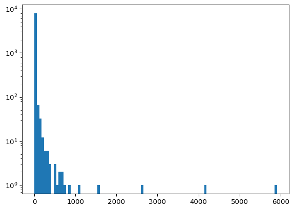

```python
import matplotlib.pyplot as plt
plt.hist(endog.values.ravel(), bins=100)
plt.yscale('log')
plt.show()
```

## 2.2 Exogenous Variables

Explanatory variables (also referred to as ‘exogenous’ or ‘covariates’) are available in the dataset:

```python
site = micro["site"]
print('Possible sites: ', site.unique())
time = micro["time"]
print('Possible times: ', time.unique())
lineage = micro["lineage"]
print('Possible lineages: ', lineage.unique())
```

```
Possible sites:  ['B' 'V' 'L' 'N']
Possible times:  ['1S' '3M' '1M' '7M']
Possible lineages:  ['minus' 'plus']
```

# 3 Model Fitting Without Zero-Inflation

To begin, we fit a `Pln` model without accounting for zero-inflation. This serves as a baseline for comparison (see this tutorial on `Pln`). In this example, we only consider the `site` covariates:

```
Setting the offsets to zero.
Fitting a Pln model with full covariance.
Intializing parameters ...
Initialization finished.
```

```
Maximum number of iterations (400)  reached in 1.3 seconds.
Last  criterion = 5.37e-06 . Required tolerance = 1e-06
```

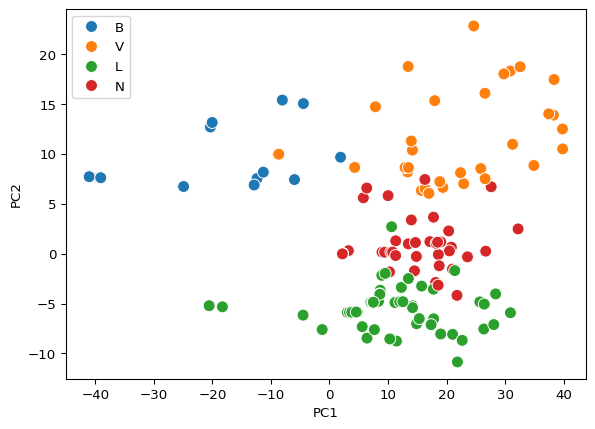

```python
from pyPLNmodels import Pln
pln = Pln.from_formula('endog ~ 1 + site', data=micro).fit()
pln.viz(colors=micro["site"])
```

# 4 Model Fitting With Zero-Inflation

Next, we fit a `ZIPln` model that accounts for zero-inflation. This model improves the handling of datasets with a high proportion of zeros:

```
`exog_inflation` and `exog` are set to the same array. If you need different `exog_inflation`, specify it with a pipe: '|' like in the following: endog ~ 1 + x | x + y
Setting the offsets to zero.
Fitting a ZIPln model with full covariance.
Intializing parameters ...
Initialization finished.
```

```
Maximum number of iterations (400)  reached in 0.9 seconds.
Last  criterion = 5.72e-06 . Required tolerance = 1e-06
```

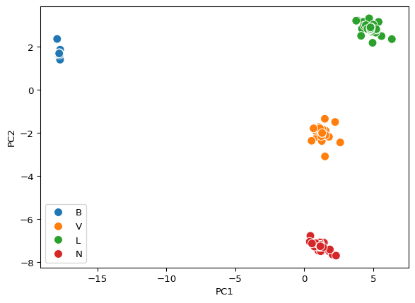

```python
from pyPLNmodels import ZIPln
zipln = ZIPln.from_formula('endog ~ 1 + site', data=micro).fit()
zipln.viz(colors=micro["site"])
```

Incorporating zero-inflation improves the model by minimizing noise in the latent variables. To explore the model further, you can print it to access detailed information, along with its available methods and attributes:

```python
print(zipln)
```

```
A multivariate ZIPln with full covariance.
======================================================================
     Loglike   Dimension    Nb param         BIC         AIC         ICL
    -2502.82          20         370   3611.2398   2872.8188    -10833.0

======================================================================
* Useful attributes
    .latent_variables .latent_positions .coef .covariance .precision .model_parameters .latent_parameters .optim_details
* Useful methods
    .transform() .show() .predict() .sigma() .projected_latent_variables() .plot_correlation_circle() .biplot() .viz() .pca_pairplot() .plot_expected_vs_true()
* Additional attributes for ZIPln are:
    .latent_prob
* Additional methods for ZIPln are:
    .viz_prob() .show_prob() .predict_prob_inflation() .pca_pairplot_prob()
```

# 5 Zero-Inflation Parameters

The `ZIPln` model includes regression parameters for the zero-inflation component. These parameters, along with other model insights, can be visualized using the `.show()` method:

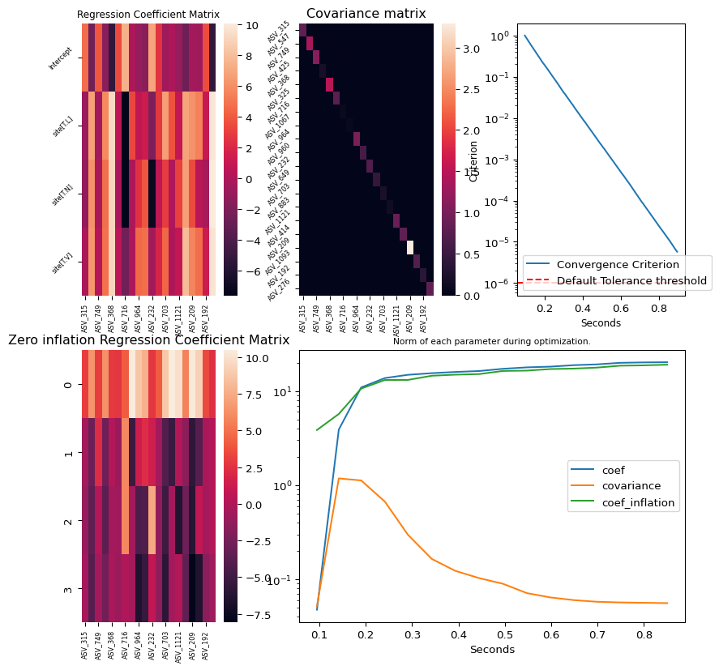

```python
zipln.show()
```

Additionally, the model infers the probability of zero-inflation for each entry in `endog`, and can be visualized using the `.show_prob()` method:

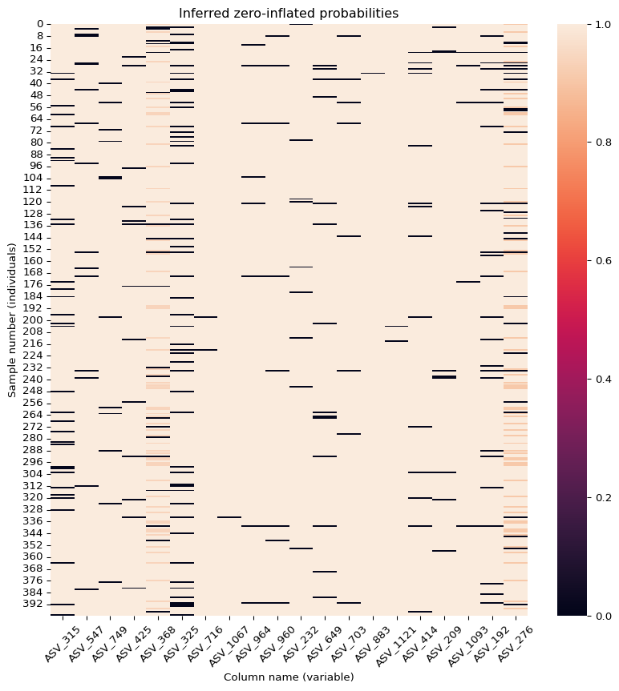

```python
zipln.show_prob()
```

This probability is naturally zero for non-zero counts. To explore the latent probability of zero-inflation, you can use the `latent_prob` attribute:

```python
print(zipln.latent_prob)
```

```
tensor([[1.0000, 0.9984, 1.0000,  ..., 0.9999, 1.0000, 0.9095],
        [1.0000, 1.0000, 1.0000,  ..., 1.0000, 1.0000, 1.0000],
        [1.0000, 1.0000, 1.0000,  ..., 1.0000, 1.0000, 1.0000],
        ...,
        [1.0000, 1.0000, 1.0000,  ..., 1.0000, 1.0000, 1.0000],
        [1.0000, 1.0000, 1.0000,  ..., 1.0000, 1.0000, 1.0000],
        [0.0000, 1.0000, 1.0000,  ..., 1.0000, 1.0000, 1.0000]])
```

# 6 Using Different Covariates for Zero-Inflation and Count Components

The `ZIPln` model allows you to specify different covariates for the zero-inflation and count components. When using formula parsing, the covariates for the zero-inflation part are separated by a `|` symbol. For example, to use the `site` covariate for the count part and the `time` covariate for the zero-inflation part:

```
Setting the offsets to zero.
Fitting a ZIPln model with full covariance.
Intializing parameters ...
Initialization finished.
```

```
Maximum number of iterations (400)  reached in 0.9 seconds.
Last  criterion = 1.397e-05 . Required tolerance = 1e-06
```

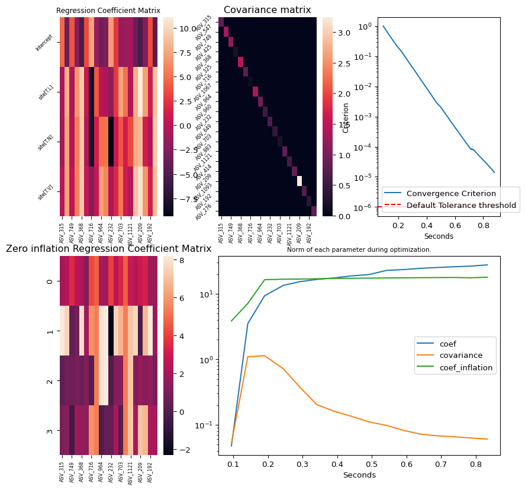

```python
zitime_pln = ZIPln.from_formula('endog ~ 1 + site | time', data=micro).fit()
zitime_pln.show()
```

If no pipe `|` is specified, the model will use the same covariates for both components.

You can also visualize the latent variables, colored by the `time` covariate:

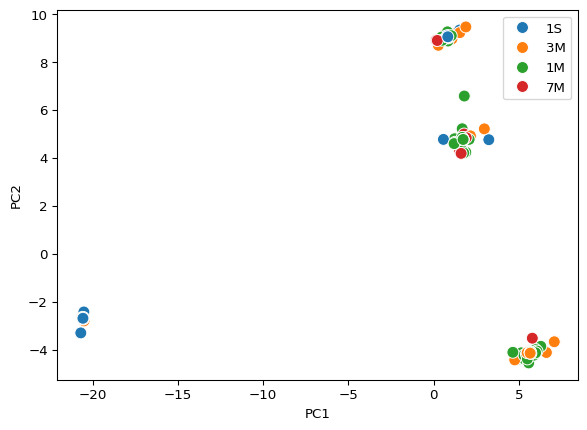

```python
zitime_pln.viz(colors=micro["time"])
```

# 7 Handling High-Dimensional Data: `ZIPlnPCA`

The `ZIPlnPCA` model is the zero-inflated counterpart of the `PlnPCA` model, designed specifically for high-dimensional datasets. It introduces a trade-off by reducing the accuracy of the covariance matrix to improve computational efficiency.

To fit a `ZIPlnPCA` model, you can specify the rank:

```python
from pyPLNmodels import ZIPlnPCA
high_d_micro = load_microcosm(dim=500)
zipca = ZIPlnPCA.from_formula('endog ~ 1 + site', data=high_d_micro, rank=5).fit()
```

```
`exog_inflation` and `exog` are set to the same array. If you need different `exog_inflation`, specify it with a pipe: '|' like in the following: endog ~ 1 + x | x + y
Setting the offsets to zero.
Now dataset of size torch.Size([400, 496]).
Fitting a ZIPlnPCA model with 5 principal components.
Intializing parameters ...
```

```
Initialization finished.
```

```
Maximum number of iterations (1000)  reached in 12.1 seconds.
Last  criterion = 1.243e-05 . Required tolerance = 9.999999999999999e-10
```

## 7.1 `ZIPlnPCACollection` for multiple ranks

The rank is a hyperparameter that can be manually defined. Alternatively, a data-driven approach to rank selection can be performed using the `ZIPlnPCACollection` class ([documentation](https://pln-team.github.io/pyPLNmodels/ziplnpcacollection.html)). This class fits multiple models with different ranks:

```python
from pyPLNmodels import ZIPlnPCACollection
zipcas = ZIPlnPCACollection.from_formula('endog ~ 1 + site', data=high_d_micro, ranks=[3, 5, 10, 15]).fit()
```

```
`exog_inflation` and `exog` are set to the same array. If you need different `exog_inflation`, specify it with a pipe: '|' like in the following: endog ~ 1 + x | x + y
Setting the offsets to zero.
Now dataset of size torch.Size([400, 496]).
Adjusting 4 ZIPlnPCA models.

Fitting a ZIPlnPCA model with 3 principal components.
Intializing parameters ...
Initialization finished.
```

```
Maximum number of iterations (1000)  reached in 12.4 seconds.
Last  criterion = 6.5e-07 . Required tolerance = 9.999999999999999e-10
Fitting a ZIPlnPCA model with 5 principal components.
Intializing parameters ...
Initialization finished.
```

```
Maximum number of iterations (1000)  reached in 12.7 seconds.
Last  criterion = 1.4e-07 . Required tolerance = 9.999999999999999e-10
Fitting a ZIPlnPCA model with 10 principal components.
Intializing parameters ...
Initialization finished.
```

```
Maximum number of iterations (1000)  reached in 12.7 seconds.
Last  criterion = 1.9e-07 . Required tolerance = 9.999999999999999e-10
Fitting a ZIPlnPCA model with 15 principal components.
Intializing parameters ...
Initialization finished.
```

```
Maximum number of iterations (1000)  reached in 14.1 seconds.
Last  criterion = 6e-08 . Required tolerance = 9.999999999999999e-10
======================================================================

DONE!
Best model (lower BIC): rank 15
    Best model(lower AIC): rank  15

======================================================================
```

## 7.2 Accessing the Best Model

The best model can be selected using the `.best_model()` method, based on a chosen criterion (`AIC`, `BIC`, or `ICL`):

```python
best_zipca = zipcas.best_model(criterion="BIC")
print(best_zipca)
```

```
A multivariate ZIPlnPCA with 15 principal components.
======================================================================
     Loglike   Dimension    Nb param         BIC         AIC         ICL
  -132633.48         496       11408 166808.7982 144041.4844    157865.3

======================================================================
* Useful attributes
    .latent_variables .latent_positions .coef .covariance .precision .model_parameters .latent_parameters .optim_details
* Useful methods
    .transform() .show() .predict() .sigma() .projected_latent_variables() .plot_correlation_circle() .biplot() .viz() .pca_pairplot() .plot_expected_vs_true()
* Additional attributes for ZIPlnPCA are:
    .latent_prob
* Additional methods for ZIPlnPCA are:
    .viz_prob() .show_prob() .predict_prob_inflation() .pca_pairplot_prob()
```

**⚠️ Note** The best model might always correspond to the largest rank, which may not always be desirable. To better understand the trade-offs, you can visualize the criteria for all models using the `.show()` method:

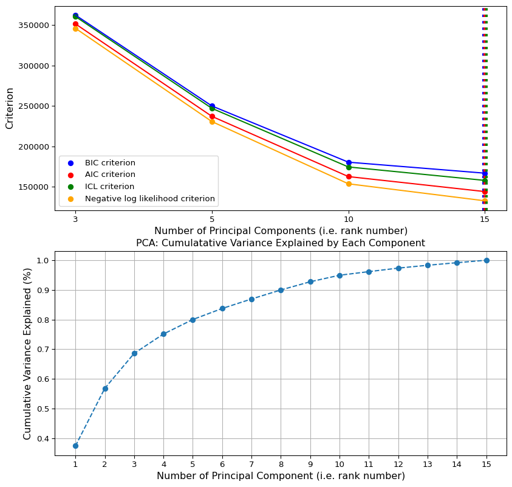

```python
zipcas.show()
```

## 7.3 Accessing Individual Models

All individual models in the collection can be accessed with the rank as the key:

```python
zipca_rank_5 = zipcas[5]
print(zipca_rank_5)
```

```
A multivariate ZIPlnPCA with 5 principal components.
======================================================================
     Loglike   Dimension    Nb param         BIC         AIC         ICL
   -230638.8         496        6448 249955.2786 237086.7969   247013.27

======================================================================
* Useful attributes
    .latent_variables .latent_positions .coef .covariance .precision .model_parameters .latent_parameters .optim_details
* Useful methods
    .transform() .show() .predict() .sigma() .projected_latent_variables() .plot_correlation_circle() .biplot() .viz() .pca_pairplot() .plot_expected_vs_true()
* Additional attributes for ZIPlnPCA are:
    .latent_prob
* Additional methods for ZIPlnPCA are:
    .viz_prob() .show_prob() .predict_prob_inflation() .pca_pairplot_prob()
```

You can also iterate through the collection to explore each model:

```python
for zipca in zipcas.values():
    print(zipca)
```

## 7.4 Additional Information

To explore the available methods and attributes of a model, simply print the model object. Some attributes, such as `coef_inflation` (coefficients for the zero-inflation component) and `latent_prob` (probabilities of zero-inflation), are specific to the `ZIPln` and `ZIPlnPCA` models.

## References

Batardière, Bastien, Julien Chiquet, François Gindraud, and Mahendra Mariadassou. 2024. “Zero-Inflation in the Multivariate Poisson Lognormal Family.” https://arxiv.org/abs/2405.14711.

Batardière, Bastien, Joon Kwon, and Julien Chiquet. 2024. “pyPLNmodels: A Python Package to Analyze Multivariate High-Dimensional Count Data.” *Journal of Open Source Software*.

Mariadassou, Mahendra, Laurent X Nouvel, Fabienne Constant, Diego P Morgavi, Lucie Rault, Sarah Barbey, Emmanuelle Helloin, et al. 2023. “Microbiota Members from Body Sites of Dairy Cows Are Largely Shared Within Individual Hosts Throughout Lactation but Sharing Is Limited in the Herd.” *Animal Microbiome* 5 (1): 1–17. https://doi.org/10.1186/s42523-023-00252-w.